### Library

```r
library(here)
library(CCA)
library(CCP)
library(scatterplot3d)
library(mvtnorm)
library(car)
library(expm)
library(GGally)
library(e1071)
library(MVN)
library(dplyr)
library(readr)
library(purrr)
library(heplots)
library(forcats)
library(pROC)

select <- dplyr::select
```

### Exploratory data analysis

```r
abalone <- read.csv("D:\\General\\abalone\\abalone.csv")
summary(abalone)
```

```
##      Sex                Length         Diameter          Height
##  Length:4177        Min.   : 15.0   Min.   : 11.00   Min.   :  0.0
##  Class :character   1st Qu.: 90.0   1st Qu.: 70.00   1st Qu.: 23.0
##  Mode  :character   Median :109.0   Median : 85.00   Median : 28.0
##                     Mean   :104.8   Mean   : 81.58   Mean   : 27.9
##                     3rd Qu.:123.0   3rd Qu.: 96.00   3rd Qu.: 33.0
##                     Max.   :163.0   Max.   :130.00   Max.   :226.0
##   Whole.weight   Shucked.weight   Viscera.weight    Shell.weight
##  Min.   :  0.4   Min.   :  0.20   Min.   :  0.10   Min.   :  0.30
##  1st Qu.: 88.3   1st Qu.: 37.20   1st Qu.: 18.70   1st Qu.: 26.00
##  Median :159.9   Median : 67.20   Median : 34.20   Median : 46.80
##  Mean   :165.7   Mean   : 71.87   Mean   : 36.12   Mean   : 47.77
##  3rd Qu.:230.6   3rd Qu.:100.40   3rd Qu.: 50.60   3rd Qu.: 65.80
##  Max.   :565.1   Max.   :297.60   Max.   :152.00   Max.   :201.00
##      Rings
##  Min.   : 1.000
##  1st Qu.: 8.000
##  Median : 9.000
##  Mean   : 9.934
##  3rd Qu.:11.000
##  Max.   :29.000
```

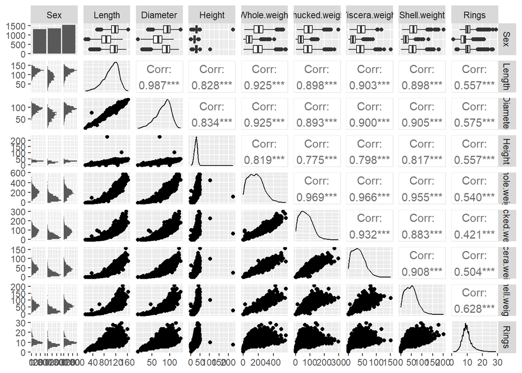

```r
ggpairs(as.data.frame(abalone))
```

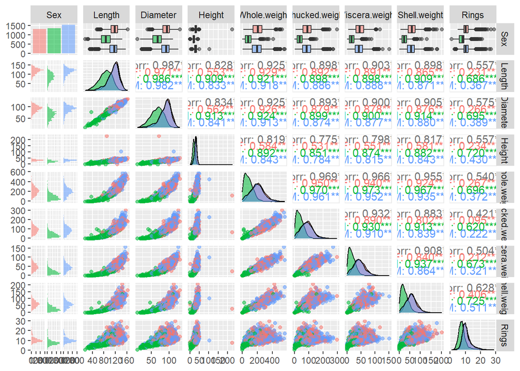

```r
ggpairs(as.data.frame(abalone), aes(colour=Sex, alpha=0.7))
```

### Data Preparation

(Remove outliers, Transform)

```r
abalone <- subset(abalone, abalone$Height > mean(abalone$Height)-4*sd(abalone$Height) & abalone$Height < mean(abalone$Height)+4*sd(abalone$Height))

ab_trans <- cbind(Sex=abalone$Sex, Length=(max(abalone[,2]+1)-abalone[,2])^(1/2), Diameter=(max(abalone[,3]+1)-abalone[,3])^(1/2), Height=abalone[,4], (abalone[,5:9])^(1/2))

mvn(ab_trans[,-1], mvnTest="mardia", univariateTest = "SW")
```

```
## $multivariateNormality
##              Test        Statistic p value Result
## 1 Mardia Skewness 8881.63733900749       0     NO
## 2 Mardia Kurtosis 291.549532284654       0     NO
## 3             MVN             <NA>    <NA>     NO
##
## $univariateNormality
##           Test       Variable Statistic   p value Normality
## 1 Shapiro-Wilk     Length        0.9958  <0.001      NO
## 2 Shapiro-Wilk    Diameter       0.9953  <0.001      NO
## 3 Shapiro-Wilk     Height        0.9930  <0.001      NO
## 4 Shapiro-Wilk  Whole.weight     0.9903  <0.001      NO
## 5 Shapiro-Wilk Shucked.weight    0.9939  <0.001      NO
## 6 Shapiro-Wilk Viscera.weight    0.9922  <0.001      NO
## 7 Shapiro-Wilk  Shell.weight     0.9918  <0.001      NO
## 8 Shapiro-Wilk     Rings         0.9720  <0.001      NO
##
## $Descriptives
##                   n      Mean   Std.Dev    Median       Min       Max      25th
## Length         4175  7.534937 1.5595696  7.416198 1.0000000 12.206556  6.403124
## Diameter       4175  6.887295 1.4122287  6.782330 1.0000000 10.954451  5.916080
## Height         4175 27.837844 7.6978335 28.000000 0.0000000 50.000000 23.000000
## Whole.weight   4175 12.205652 4.0889578 12.645157 0.6324555 23.771832  9.396808
## Shucked.weight 4175  8.011008 2.7684944  8.197561 0.4472136 17.251087  6.099180
## Viscera.weight 4175  5.685673 1.9445287  5.848077 0.3162278 12.328828  4.318561
## Shell.weight   4175  6.568447 2.1481939  6.841053 0.5477226 14.177447  5.099020
## Rings          4175  3.112700 0.4952697  3.000000 1.0000000  5.385165  2.828427
##                     75th       Skew   Kurtosis
## Length          8.602325  0.1213068 -0.2144150
## Diameter        7.810250  0.1100479 -0.2631023
## Height         33.000000 -0.2643464 -0.1381039
## Whole.weight   15.185519 -0.2378974 -0.4415290
## Shucked.weight 10.017484 -0.1434628 -0.3613537
## Viscera.weight  7.109851 -0.1845946 -0.4730625
## Shell.weight    8.108637 -0.2231078 -0.2931323
## Rings           3.316625  0.4706773  1.0036552
```

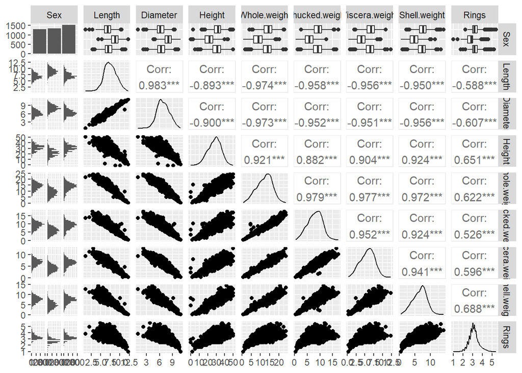

```r
ggpairs(as.data.frame(ab_trans))
```

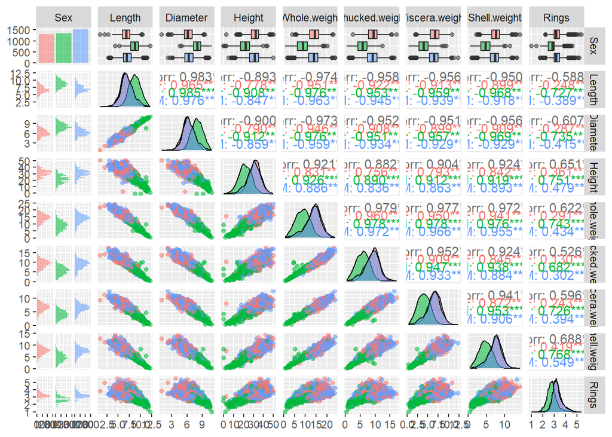

```r
ggpairs(as.data.frame(ab_trans), aes(colour=Sex, alpha=0.7))
```

### Initial observations

There is *high correlation* between the quantitative variables. These can be classed into three groups based on the scale of measurement: size (Length, Diameter, Height), weight (Whole wt., Shucked wt., Viscera wt., Shell wt.) and age (integer). For this data, high correlation within and between each group makes sense. The Mardia and Shapiro-Wilk’s diagnostics indicate that despite the transformation, the resulting dataset is not consistent with normality. However, given the large sample size, this transformation is likely adequate for most statistical procedures.

# *Question 1*

One approach to predict the sex of abalone is the use of classification techniques. These include Linear Discriminant Analysis (LDA), Quadratic Discriminant Analysis (QDA), and Support Vector Machines (SVM).

##### LDA Assumptions *

- Normally distributed and a class-specific mean vector
- Each category has equal covariance matrices

##### QDA Assumptions *

- Observations drawn from normal distribution
- Each category has different covariance matrices

##### SVM Assumptions

- Margins should be as large as possible
- Support vectors are the most useful data points (as they are most likely to be incorrectly classified)

Source* https://thatdatatho.com/assumption-checking-lda-vs-qda-r-tutorial-2/

### Test for Homogeneity of Covariance Matrices

Equal covariance assumption will determine what type of classifier is most suitable for this data set. A visual inspection of the boxplots for Sex vs Length, Sex vs Diameter, and Sex vs Height show similar variance between the sex categories.

```r
boxM(ab_trans[,2:4],ab_trans$Sex)
```

```
##
##  Box's M-test for Homogeneity of Covariance Matrices
##
## data:  ab_trans[, 2:4]
## Chi-Sq (approx.) = 572.8, df = 12, p-value < 2.2e-16
```

https://www.statisticshowto.com/boxs-m-test/

The Box’s M-test returns a significant result indicating the covariance matrices are not homogeneous. It should be noted that the Box’s M-test is extremely sensitive to departures from normality. In the case where neither normality nor homogeneity of co-variances are satisfied, the most appropriate classifier is Support Vector Machines.

### Preparing Categorical Data

```r
all<-female<-male<-infant<- abalone %>% select(Sex,Length,Diameter,Height) %>% mutate(Sex=factor(Sex))

female$Sex <- fct_collapse(female$Sex, Other = c("M","I"))

male$Sex <- fct_collapse(male$Sex, Other = c("F","I"))

infant$Sex <- fct_collapse(infant$Sex, Other = c("F","M"))
```

In preparing for SVM, the data was transformed using a *One-against-rest* approach where the probability of each category was predicted against all others. As such, four data sets were created with alterations to the Sex categories as per below:

- Set 1: Sex categories unchanged
- Set 2: Non-Females categories classified as “Others”
- Set 3: Non-Males categories classified as “Others”
- Set 4: Non-Infants categories classified as “Others”

### Tuning SVM

```r
#summary(tune.rad <- tune.svm(Sex~Height+Diameter+Length, data=all, kernel="radial", gamma = 10^(-1:0), cost = 10^(-1:0)))

#summary(tune.sig <- tune.svm(Sex~Height+Diameter+Length, data=all, kernel="sigmoid"))

#tune.rad$best.performance
#tune.sig$best.performance
```

### Fitting SVM

```r
all.svm <- svm(Sex~Height+Diameter+Length, data=all, kernel="radial", cross=10)
female.svm <- svm(Sex~Height+Diameter+Length, data=female, kernel="radial", cross=10)
male.svm <- svm(Sex~Height+Diameter+Length, data=male, kernel="radial", cross=10)
infant.svm <- svm(Sex~Height+Diameter+Length, data=infant, kernel="radial", cross=10)

summary(all.svm)
```

```
##
## Call:
## svm(formula = Sex ~ Height + Diameter + Length, data = all, kernel = "radial",
##     cross = 10)
##
##
## Parameters:
##    SVM-Type:  C-classification
##  SVM-Kernel:  radial
##        cost:  1
##
## Number of Support Vectors:  3580
##
##  ( 1505 1304 771 )
##
##
## Number of Classes:  3
##
## Levels:
##  F I M
##
## 10-fold cross-validation on training data:
##
## Total Accuracy: 52.26347
## Single Accuracies:
##  47.24221 49.2823 53.47722 56.69856 53.23741 53.34928 50.1199 53.82775 52.27818 53.11005
```

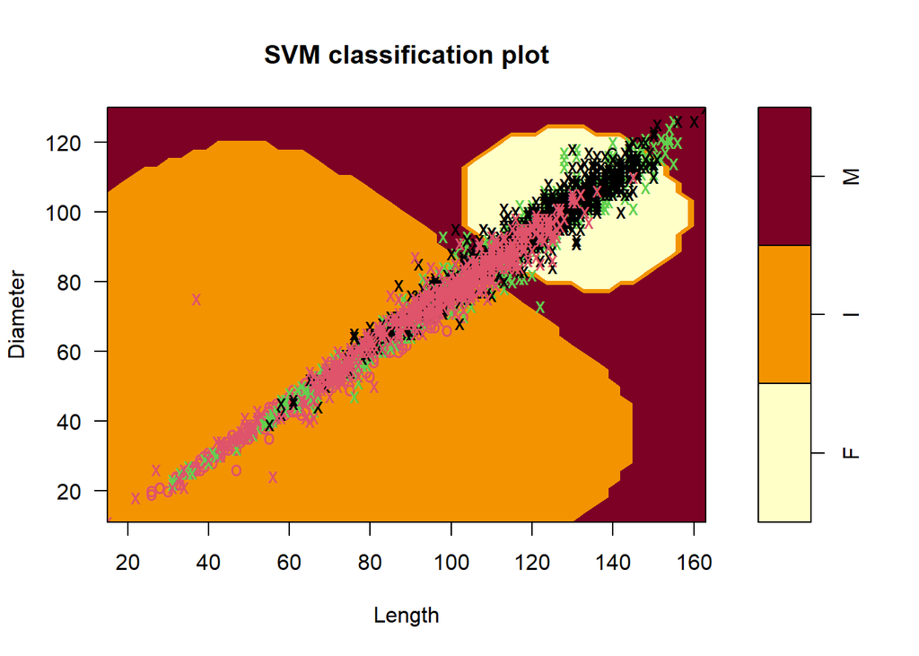

```r
plot(all.svm, data=all, Diameter~Length)
```

```r
summary(female.svm)
```

```
##
## Call:
## svm(formula = Sex ~ Height + Diameter + Length, data = female, kernel = "radial",
##     cross = 10)
##
##
## Parameters:
##    SVM-Type:  C-classification
##  SVM-Kernel:  radial
##        cost:  1
##
## Number of Support Vectors:  2720
##
##  ( 1414 1306 )
##
##
## Number of Classes:  2
##
## Levels:
##  F Other
##
## 10-fold cross-validation on training data:
##
## Total Accuracy: 68.67066
## Single Accuracies:
##  68.34532 68.89952 68.82494 66.74641 67.86571 69.85646 70.26379 73.20574 62.11031 70.57416
```

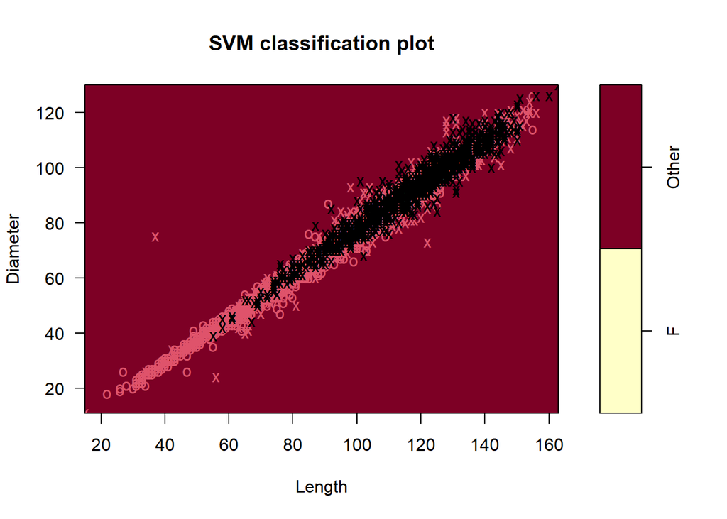

```r
plot(female.svm, data=female, Diameter~Length)
```

```r
summary(male.svm)
```

```
##
## Call:
## svm(formula = Sex ~ Height + Diameter + Length, data = male, kernel = "radial",
##     cross = 10)
##
##
## Parameters:
##    SVM-Type:  C-classification
##  SVM-Kernel:  radial
##        cost:  1
##
## Number of Support Vectors:  3263
##
##  ( 1527 1736 )
##
##
## Number of Classes:  2
##
## Levels:
##  Other M
##
## 10-fold cross-validation on training data:
##
## Total Accuracy: 63.20958
## Single Accuracies:
##  63.30935 62.20096 64.50839 64.35407 60.91127 61.48325 64.98801 61.00478 62.58993 66.74641
```

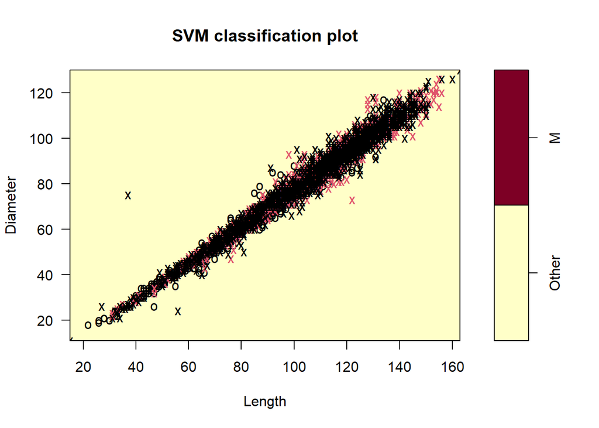

```r
plot(male.svm, data=male, Diameter~Length)
```

```r
summary(infant.svm)
```

```
##
## Call:
## svm(formula = Sex ~ Height + Diameter + Length, data = infant, kernel = "radial",
##     cross = 10)
##
##
## Parameters:
##    SVM-Type:  C-classification
##  SVM-Kernel:  radial
##        cost:  1
##
## Number of Support Vectors:  1823
##
##  ( 915 908 )
##
##
## Number of Classes:  2
##
## Levels:
##  Other I
##
## 10-fold cross-validation on training data:
##
## Total Accuracy: 79.25749
## Single Accuracies:
##  74.82014 77.03349 79.13669 80.62201 79.13669 78.70813 79.13669 82.05742 82.2542 79.66507
```

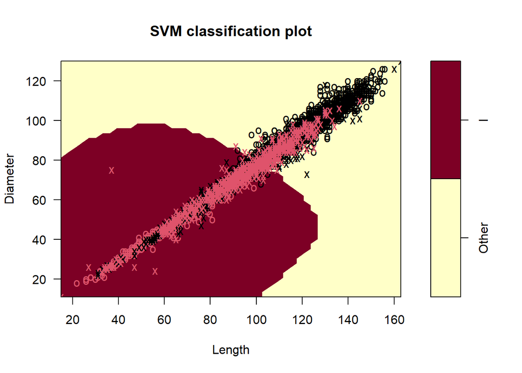

```r
plot(infant.svm, data=infant, Diameter~Length)
```

### Prediction

Using the SVM to predict the Sex of an abalone with Height=45, Length=120, Diameter=90. The predicted category is Male.

```r
predict(all.svm, newdata=data.frame(Height=45, Length=120, Diameter=90), decision.values = TRUE)
```

```
## 1
## M
## attr(,"decision.values")
##         M/F       M/I      F/I
## 1 0.4749014 0.9955997 1.003241
## Levels: F I M
```

### Testing of accuracy

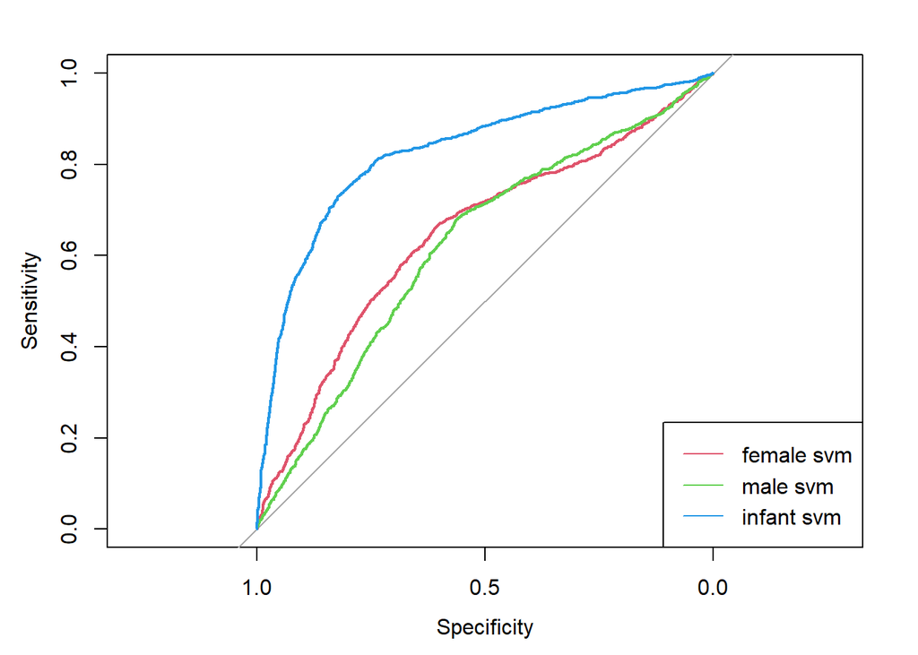

```r
female.predict <- c(attr(predict(female.svm, newdata = female, decision.values = TRUE), "decision.values"))
female.roc <- roc(female$Sex=="F", female.predict)

male.predict <- c(attr(predict(male.svm, newdata = male, decision.values = TRUE), "decision.values"))
male.roc <- roc(male$Sex=="M", male.predict)

infant.predict <- c(attr(predict(infant.svm, newdata = infant, decision.values = TRUE), "decision.values"))
infant.roc <- roc(infant$Sex=="I", infant.predict)

plot(female.roc, col=2)
plot(male.roc, col=3, add=TRUE)
plot(infant.roc, col=4, add=TRUE)

legend("bottomright", c("female svm", "male svm", "infant svm"), lty=1, col=2:4 )
```

To conclude on the classifier performance, we turn to the ROC curve with plots sensitivity vs specificity. Sensitivity is the proportion of true positives, while specificity is the proportion of true negatives. A perfect model would score 1 on both axis, creating a step, while a model that is little better than chance would straddle the diagonal line. We can see from the ROC curves our model performed significantly better when classifying infant abalone compared to male and female abalone. We see this was a result of the significant overlap in sizes for the mature adults and the type of measurements used. It would appear that while weight and size measurements are able to easily distinguish infant from adult abalone, that is not the case between male and female abalone as they are similar in size and weight.

# *Question 2*

One approach to predict the shucked and visceral weights of abalone from its size, is the use of canonical correlations. Canonical correlations measure the largest possible correlation between a linear combination of the variables in the first set and a linear combination of the variables in the second set.

##### Canonical correlation assumptions *

- variables are multivariate normal
- Large sample size
- absence of multicollinearity (variable correlations =1)

* https://www.projectguru.in/performing-canonical-correlation-analysis-cca/

[figure not shown]

### Canonical Correlations

```r
X <- abalone[2:4]
Y <- abalone[6:7]
abalone.cc <- cc(X,Y)

abalone.cc$cor
```

```
## [1] 0.9220868 0.1530895
```

```r
abalone.cc$xcoef
```

```
##                  [,1]        [,2]
## Length   -0.025532805  0.06559290
## Diameter -0.008811676  0.03191349
## Height   -0.030025073 -0.30251213
```

```r
abalone.cc$ycoef
```

```
##                       [,1]       [,2]
## Shucked.weight -0.00951071  0.0614287
## Viscera.weight -0.02717104 -0.1228541
```

All coefficients corresponding to the highest canonical correlation are negative for each variable.

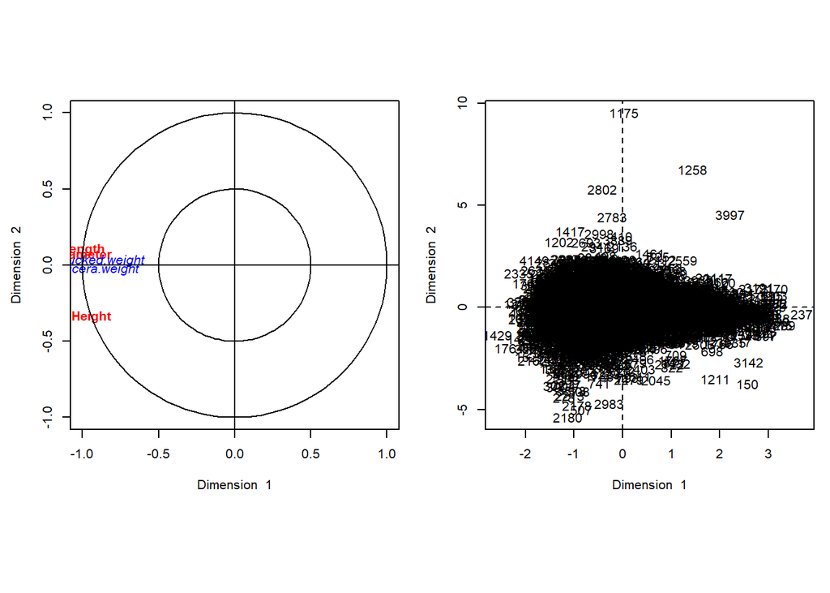

```r
plt.cc(abalone.cc, var.label = TRUE)
```

### Testing Linear Relationship

```r
n <- nrow(abalone)
p <- ncol(X)
q <- ncol(Y)
p.asym(abalone.cc$cor, n, p, q, tstat="Wilks")
```

```
## Wilks' Lambda, using F-approximation (Rao's F):
##               stat     approx df1  df2 p.value
## 1 to 2:  0.1462462 2244.73303   6 8340       0
## 2 to 2:  0.9765636   50.04956   2 4171       0
```

```r
p.asym(abalone.cc$cor, n, p, q, tstat="Pillai")
```

```
##  Pillai-Bartlett Trace, using F-approximation:
##                stat     approx df1  df2 p.value
## 1 to 2:  0.87368045 1078.47463   6 8342       0
## 2 to 2:  0.02343638   49.47983   2 8346       0
```

```r
p.asym(abalone.cc$cor, n, p, q, tstat="Roy")
```

```
##  Roy's Largest Root, using F-approximation:
##               stat   approx df1  df2 p.value
## 1 to 1:  0.8502441 11843.33   2 4172       0
##
##  F statistic for Roy's Greatest Root is an upper bound.
```

### Prediction (Value)

To predict the weight and value of abalone, we will utilise the first canonical correlation. Similar to Principal components, we can multiply the canonical coefficients by -1 without changing the interpretation of covariance and canonical correlations.

```r
cc_y <- cbind(abalone.cc$ycoef[1]*Y$Shucked.weight*-1,
              abalone.cc$ycoef[2]*Y$Viscera.weight*-1)
cc_x <- cbind(abalone.cc$xcoef[1]*X$Length*-1,
              abalone.cc$xcoef[2]*X$Diameter*-1,
              abalone.cc$xcoef[3]*X$Height*-1)

cc_cov <- cov(cbind(cc_y,cc_x))

rownames(cc_cov) <- colnames(cc_cov) <- c("Shucked.weight","Viscera.weight","Length", "Diameter","Height")

cc_cov
```

```
##                Shucked.weight Viscera.weight    Length   Diameter     Height
## Shucked.weight     0.17785661     0.23392322 0.2322816 0.06588811 0.08152699
## Viscera.weight     0.23392322     0.35429695 0.3296322 0.09365868 0.11909919
## Length             0.23228164     0.32963220 0.3760358 0.10582274 0.12753512
## Diameter           0.06588811     0.09365868 0.1058227 0.03058208 0.03662313
## Height             0.08152699     0.11909919 0.1275351 0.03662313 0.05342016
```

```r
(Mu_y <- colMeans(cc_y))
```

```
## [1] 0.6832396 0.9810690
```

```r
(Mu_x <- colMeans(cc_x))
```

```
## [1] 2.6756606 0.7187795 0.8358333
```

Utilising the following property of the multivariate normal:

$$Nr(μ_{(1)}+Σ_{12}Σ_{22}^{−1}(x_{(2)}−μ_{(2)}),Σ_{11}−Σ_{12}Σ_{22}^{−1}Σ_{21})$$

We can predict the weight and value of an abalone with Length=120, Diameter=90, Height=45, and assuming $1/gram of shucked and viscera weight.

```r
ab1 <- (c(120, 90, 45)*abalone.cc$xcoef[1:3])*-1
price <- c(1,1)

weights <- Mu_y + (cc_cov[1:2,3:5]%*%solve(cc_cov[3:5,3:5])%*%as.matrix(ab1-Mu_x))

#~~ reverse the transformation to the original data before obtaining price

(weights <- weights^2)
```

```
##                     [,1]
## Shucked.weight 0.9995928
## Viscera.weight 2.4528812
```

```r
(value <- price%*%weights)
```

```
##          [,1]
## [1,] 3.452474
```

The estimated value of the abalone is $3.45 with expected shucked and viscera weights of 1 and 2.45 grams respectively.

### Prediction Interval (Value)

A prediction interval for the true value of the abalone (90% of the time)

$$n(y−μ)^{⊤}S^{−1}(y−μ)≤F_{1−α,p,n−p}\frac{p}{n−p}(n−1)$$

[figure not shown]

```r
y_cov<-cc_cov[1:2,1:2]

y_cov.inv <- solve(y_cov)

in_ellipsoid_y <- function(x){
  q <- length(Mu_y)
  n*(Mu_y-x)%*%y_cov.inv%*%(Mu_y-x) <=q*(n-1)/(n-q) * qf(0.9, q, n-q)
}


s <- seq(0.67, 0.7, length.out=100)
v <- seq(0.95, 1.01, length.out=100)
sv <- as.matrix(expand.grid(s,v))

zz <- apply(sv, 1, in_ellipsoid_y)

plot(sv[,1], sv[,2], col=zz, xlab="Shucked.weight", ylab="Viscera.weight", pch=".", asp=1)
points(Mu_y[1], Mu_y[2], col=2)

y_S.e <- eigen(y_cov)
scl_y <- q*(n-1)/(n-q)*qf(0.9, q, n-q)/n

#1st axis (largest)
lines(rbind(Mu_y+y_S.e$vectors[,1]*sqrt(y_S.e$values[1]*scl_y), Mu_y-y_S.e$vectors[,1]*sqrt(y_S.e$values[1]*scl_y)))

#2nd axis
lines(rbind(Mu_y+y_S.e$vectors[,2]*sqrt(y_S.e$values[2]*scl_y), Mu_y-y_S.e$vectors[,2]*sqrt(y_S.e$values[2]*scl_y)))
```

The prediction interval is the ellipsoid with major and minor axis at the points

```r
pred_pts <- rbind(Mu_y+y_S.e$vectors[,1]*sqrt(y_S.e$values[1]*scl_y),
Mu_y-y_S.e$vectors[,1]*sqrt(y_S.e$values[1]*scl_y),
Mu_y+y_S.e$vectors[,2]*sqrt(y_S.e$values[2]*scl_y),
Mu_y-y_S.e$vectors[,2]*sqrt(y_S.e$values[2]*scl_y))

colnames(pred_pts) <- c("Shucked.weight","Viscera.weight")
pred_pts
```

```
##      Shucked.weight Viscera.weight
## [1,]      0.6968167      1.0006998
## [2,]      0.6696626      0.9614381
## [3,]      0.6797754      0.9834649
## [4,]      0.6867038      0.9786731
```